# Hmk1

Author

Ziyi Tao

Link for GitHub : https://github.com/t-aozy/Hmk1_STAT506

## Problem 1 - Wine Data

## a. Import data and name columns

The file is imported from “D:/wine/” in my environment. According to the information provided by the data set, columns are named as : “class”, “alcohol”, “malicacid”, “ash”, “alcalinity_of_ash”, “magnesim”, “total_phenols”, “flava”, “nonflav_phenols”, “proantho”, “color_intensity”, “hue”, “diluted_wines”, “proline”.

```r
library(DT)
```

```r
# a import data and name columns}
data_wine <- read.table("D:/wine/wine.data", sep = ",")
names(data_wine) <- c("class", "alcohol", "malicacid", "ash",
                      "alcalinity_of_ash", "magnesim",
                      "total_phenols", "flava", "nonflav_phenols",
                      "proantho", "color_intensity", "hue",
                      "diluted_wines", "proline")

datatable(data_wine, width =  "auto")
```

|  | class | alcohol | malicacid | ash | alcalinity_of_ash | magnesim | total_phenols | flava | nonflav_phenols | proantho | color_intensity | hue | diluted_wines | proline |
| --- | --- | --- | --- | --- | --- | --- | --- | --- | --- | --- | --- | --- | --- | --- |
| 1 | 1 | 14.23 | 1.71 | 2.43 | 15.6 | 127 | 2.8 | 3.06 | 0.28 | 2.29 | 5.64 | 1.04 | 3.92 | 1065 |
| 2 | 1 | 13.2 | 1.78 | 2.14 | 11.2 | 100 | 2.65 | 2.76 | 0.26 | 1.28 | 4.38 | 1.05 | 3.4 | 1050 |
| 3 | 1 | 13.16 | 2.36 | 2.67 | 18.6 | 101 | 2.8 | 3.24 | 0.3 | 2.81 | 5.68 | 1.03 | 3.17 | 1185 |
| 4 | 1 | 14.37 | 1.95 | 2.5 | 16.8 | 113 | 3.85 | 3.49 | 0.24 | 2.18 | 7.8 | 0.86 | 3.45 | 1480 |
| 5 | 1 | 13.24 | 2.59 | 2.87 | 21 | 118 | 2.8 | 2.69 | 0.39 | 1.82 | 4.32 | 1.04 | 2.93 | 735 |
| 6 | 1 | 14.2 | 1.76 | 2.45 | 15.2 | 112 | 3.27 | 3.39 | 0.34 | 1.97 | 6.75 | 1.05 | 2.85 | 1450 |
| 7 | 1 | 14.39 | 1.87 | 2.45 | 14.6 | 96 | 2.5 | 2.52 | 0.3 | 1.98 | 5.25 | 1.02 | 3.58 | 1290 |
| 8 | 1 | 14.06 | 2.15 | 2.61 | 17.6 | 121 | 2.6 | 2.51 | 0.31 | 1.25 | 5.05 | 1.06 | 3.58 | 1295 |
| 9 | 1 | 14.83 | 1.64 | 2.17 | 14 | 97 | 2.8 | 2.98 | 0.29 | 1.98 | 5.2 | 1.08 | 2.85 | 1045 |
| 10 | 1 | 13.86 | 1.35 | 2.27 | 16 | 98 | 2.98 | 3.15 | 0.22 | 1.85 | 7.22 | 1.01 | 3.55 | 1045 |

[output cut: 168 more lines]

## b. Classes of wine

According to the result of R code, there are 3 classes of wines. Class 1 has 59 instances, class 2 has 71 instances and class 3 has 48 instances, this is the same as the information provided by file wine.names.

```r
table(data_wine$class)
```

```
 1  2  3
59 71 48
```

## c. Use the data to answer following questions

### 1. The correlation between alcohol content and color intensity

R result shows the correlation coefficient is 0.546. The correlation between alcohol content and color intensity is positive, wines with higher alcohol content are likely to have higher color intensity.

```r
alcohol_color <- cor(data_wine$alcohol, data_wine$color_intensity)

cat("Correlation between alcohol and color intensity:",alcohol_color)
```

```
Correlation between alcohol and color intensity: 0.5463642
```

### 2. Class with the highest and the lowest correlation

R result shows that class 1 has the highest correlation and class 2 has the lowest correlation.

```r
# extract data from each class using index search
wine_c1 <- data_wine[data_wine["class"] == 1,]
wine_c2 <- data_wine[data_wine["class"] == 2,]
wine_c3 <- data_wine[data_wine["class"] == 3,]


# calculate the correlation in each class
r_c1 <- cor(wine_c1$alcohol, wine_c1$color_intensity)
r_c2 <- cor(wine_c2$alcohol, wine_c2$color_intensity)
r_c3 <- cor(wine_c3$alcohol, wine_c3$color_intensity)

cat(" Correlation of Class 1:", r_c1, "\n",
    "Correlation of Class 2:", r_c2, "\n",
    "Correlation of Class 3:", r_c3, "\n")
```

```
 Correlation of Class 1: 0.4082913
 Correlation of Class 2: 0.2697891
 Correlation of Class 3: 0.3503777
```

### 3. Alcohol content of the wine with the highest color intensity

The Alcohol content of the wine with the highest color intensity is 14.34.

```r
# calculate the maximum of color_intensity
color_max <- max(data_wine$color_intensity)

# filter data
data_wine[data_wine$color_intensity == color_max, "alcohol"]
```

```
[1] 14.34
```

### 4. Percentage of wines with higher content of proanthocyanins compare to ash

The Percentage of wines with higher content of proanthocyanins compare to ash is 8.43%.

```r
# define condition
condition <- (data_wine$proantho > data_wine$ash)

# filter data
proanto_higher_ash <- data_wine[condition == TRUE,]
percentage <- nrow(proanto_higher_ash*1.0)/nrow(data_wine)
cat("Percentage:", percentage)
```

```
Percentage: 0.08426966
```

## d. Create table

```r
# calculate mean value
total_aver <- sapply(data_wine[,2:length(data_wine)], mean)
c1_aver <- sapply(wine_c1[,2:length(data_wine)], mean)
c2_aver <- sapply(wine_c2[,2:length(data_wine)], mean)
c3_aver <- sapply(wine_c3[,2:length(data_wine)], mean)

# form a table
datatable(
  round(
    as.data.frame(rbind(total_aver, c1_aver, c2_aver, c3_aver),
                  width =  "auto"),
    digits = 4
  )

)
```

|  | alcohol | malicacid | ash | alcalinity_of_ash | magnesim | total_phenols | flava | nonflav_phenols | proantho | color_intensity | hue | diluted_wines | proline |
| --- | --- | --- | --- | --- | --- | --- | --- | --- | --- | --- | --- | --- | --- |
| total_aver | 13.0006 | 2.3363 | 2.3665 | 19.4949 | 99.7416 | 2.2951 | 2.0293 | 0.3619 | 1.5909 | 5.0581 | 0.9574 | 2.6117 | 746.8933 |
| c1_aver | 13.7447 | 2.0107 | 2.4556 | 17.0373 | 106.339 | 2.8402 | 2.9824 | 0.29 | 1.8993 | 5.5283 | 1.062 | 3.1578 | 1115.7119 |
| c2_aver | 12.2787 | 1.9327 | 2.2448 | 20.238 | 94.5493 | 2.2589 | 2.0808 | 0.3637 | 1.6303 | 3.0866 | 1.0563 | 2.7854 | 519.507 |
| c3_aver | 13.1538 | 3.3338 | 2.4371 | 21.4167 | 99.3125 | 1.6787 | 0.7815 | 0.4475 | 1.1535 | 7.3962 | 0.6827 | 1.6835 | 629.8958 |

## e. T test

Yes, according to T test, the level of phenols differs across the three class, p-value < 0.05.

Strictly, we need first to test some assumptions before conduct t-test. So I also list the assumption test results below.

```r
t.test(wine_c1$total_phenols, wine_c2$total_phenols)
```

```
    Welch Two Sample t-test

data:  wine_c1$total_phenols and wine_c2$total_phenols
t = 7.4206, df = 119.14, p-value = 1.889e-11
alternative hypothesis: true difference in means is not equal to 0
95 percent confidence interval:
 0.4261870 0.7364055
sample estimates:
mean of x mean of y
 2.840169  2.258873
```

```r
t.test(wine_c1$total_phenols, wine_c3$total_phenols)
```

```
    Welch Two Sample t-test

data:  wine_c1$total_phenols and wine_c3$total_phenols
t = 17.12, df = 98.356, p-value < 2.2e-16
alternative hypothesis: true difference in means is not equal to 0
95 percent confidence interval:
 1.026801 1.296038
sample estimates:
mean of x mean of y
 2.840169  1.678750
```

```r
t.test(wine_c2$total_phenols, wine_c3$total_phenols)
```

```
    Welch Two Sample t-test

data:  wine_c2$total_phenols and wine_c3$total_phenols
t = 7.0125, df = 116.91, p-value = 1.622e-10
alternative hypothesis: true difference in means is not equal to 0
95 percent confidence interval:
 0.4162855 0.7439610
sample estimates:
mean of x mean of y
 2.258873  1.678750
```

```r
# normal distribution test
shapiro.test(wine_c1$total_phenols)
```

```
    Shapiro-Wilk normality test

data:  wine_c1$total_phenols
W = 0.95174, p-value = 0.0203
```

```r
shapiro.test(wine_c2$total_phenols)
```

```
    Shapiro-Wilk normality test

data:  wine_c2$total_phenols
W = 0.98004, p-value = 0.318
```

```r
shapiro.test(wine_c3$total_phenols)
```

```
    Shapiro-Wilk normality test

data:  wine_c3$total_phenols
W = 0.93967, p-value = 0.01577
```

```r
# homoskedasticity test
var.test(total_phenols~class, data = data_wine[data_wine$class %in% c(1, 2),])
```

```
    F test to compare two variances

data:  total_phenols by class
F = 0.38631, num df = 58, denom df = 70, p-value = 0.0002658
alternative hypothesis: true ratio of variances is not equal to 1
95 percent confidence interval:
 0.2364740 0.6384943
sample estimates:
ratio of variances
         0.3863066
```

```r
var.test(total_phenols~class, data = data_wine[data_wine$class %in% c(1, 3),])
```

```
    F test to compare two variances

data:  total_phenols by class
F = 0.90164, num df = 58, denom df = 47, p-value = 0.7028
alternative hypothesis: true ratio of variances is not equal to 1
95 percent confidence interval:
 0.5160236 1.5504090
sample estimates:
ratio of variances
         0.9016435
```

```r
var.test(total_phenols~class, data = data_wine[data_wine$class %in% c(2, 3),])
```

```
    F test to compare two variances

data:  total_phenols by class
F = 2.334, num df = 70, denom df = 47, p-value = 0.00251
alternative hypothesis: true ratio of variances is not equal to 1
95 percent confidence interval:
 1.357364 3.903725
sample estimates:
ratio of variances
           2.33401
```

## e.plus Calculate p-values

```r
# calculate sample size and sample std
n1 <- nrow(wine_c1)
n2 <- nrow(wine_c2)
n3 <- nrow(wine_c3)

mean1 <- mean(wine_c1$total_phenols)
mean2 <- mean(wine_c2$total_phenols)
mean3 <- mean(wine_c3$total_phenols)

# sample std
s1 <- sd(wine_c1$total_phenols)
s2 <- sd(wine_c2$total_phenols)
s3 <- sd(wine_c3$total_phenols)
```

```r
#' sp
#'
#' @param n1 sample size of sample1
#' @param n2 sample size of sample2
#' @param s1 standard deviation of sample1
#' @param s2 standard deviation of sample2
#'
#' @return
#'  the sp value of two samples with sample size n1, n2, standard deviation s1, s2

sp <- function(n1, n2, s1, s2){
  sqrt(((n1-1)*s1^2 + (n2-1)*s2^2)/(n1+n2-2))
}
```

```r
#' t
#'
#' @param m1 mean value of sample1
#' @param m2 mean value of sample2
#' @param n_1 sample size of sample1
#' @param n_2 sample size of sample2
#' @param sp_ sp value
#'
#' @return
#'  t score of two samples with average values m1, m2, sample size n1, n2, sp value
t <- function(m1, m2, n_1, n_2, sp_){
  return ((m1-m2)/(sp_*sqrt(1/n_1+1/n_2)))
}
```

```r
t_12 <- t(mean1, mean2, n1, n2, sp(n1, n2, s1, s2))
t_13 <- t(mean1, mean3, n1, n3, sp(n1, n3, s1, s3))
t_23 <- t(mean2, mean3, n2, n3, sp(n2, n3, s2, s3))

cat(" p-value c1&c2:",
    2*pt(t_12, (n1+n2-2), lower.tail = FALSE),"\n",
    "p-value c1&c3:",
    2*pt(t_13, (n1+n3-2),lower.tail = FALSE), "\n",
    "p-value c2&c3:",
    2*pt(t_23, (n2+n3-2),lower.tail = FALSE)
    )
```

```
 p-value c1&c2: 6.865291e-11
 p-value c1&c3: 2.437614e-32
 p-value c2&c3: 2.203376e-09
```

## Problem 2 - AskAManager

## a. Import data

The file is imported from “D:/” in my environment.

```r
data_manager <- read.table("D:/AskAManager.csv", sep = ",", header = TRUE)
datatable(head(data_manager), width =  "auto")
```

|  | X | Timestamp | How.old.are.you. | What.industry.do.you.work.in. | Job.title | If.your.job.title.needs.additional.context..please.clarify.here. | What.is.your.annual.salary...You.ll.indicate.the.currency.in.a.later.question..If.you.are.part.time.or.hourly..please.enter.an.annualized.equivalent....what.you.would.earn.if.you.worked.the.job.40.hou… | How.much.additional.monetary.compensation.do.you.get..if.any..for.example..bonuses.or.overtime.in.an.average.year...Please.only.include.monetary.compensation.here..not.the.value.of.benefits. | Please.indicate.the.currency | If..Other...please.indicate.the.currency.here.. | If.your.income.needs.additional.context..please.provide.it.here. | What.country.do.you.work.in. | If.you.re.in.the.U.S...what.state.do.you.work.in. | What.city.do.you.work.in. | How.many.years.of.professional.work.experience.do.you.have.overall. | How.many.years.of.professional.work.experience.do.you.have.in.your.field. | What.is.your.highest.level.of.education.completed. | What.is.your.gender. | What.is.your.race...Choose.all.that.apply.. |
| --- | --- | --- | --- | --- | --- | --- | --- | --- | --- | --- | --- | --- | --- | --- | --- | --- | --- | --- | --- |
| 1 | 1 | 4/27/2021 11:02:10 | 25-34 | Education (Higher Education) | Research and Instruction Librarian |  | 55000 | 0 | USD |  |  | United States | Massachusetts | Boston | 5-7 years | 5-7 years | Master's degree | Woman | White |
| 2 | 2 | 4/27/2021 11:02:22 | 25-34 | Computing or Tech | Change &amp; Internal Communications Manager |  | 54600 | 4000 | GBP |  |  | United Kingdom |  | Cambridge | 8 - 10 years | 5-7 years | College degree | Non-binary | White |
| 3 | 3 | 4/27/2021 11:02:38 | 25-34 | Accounting, Banking &amp; Finance | Marketing Specialist |  | 34000 |  | USD |  |  | US | Tennessee | Chattanooga | 2 - 4 years | 2 - 4 years | College degree | Woman | White |
| 4 | 4 | 4/27/2021 11:02:41 | 25-34 | Nonprofits | Program Manager |  | 62000 | 3000 | USD |  |  | USA | Wisconsin | Milwaukee | 8 - 10 years | 5-7 years | College degree | Woman | White |
| 5 | 5 | 4/27/2021 11:02:42 | 25-34 | Accounting, Banking &amp; Finance | Accounting Manager |  | 60000 | 7000 | USD |  |  | US | South Carolina | Greenville | 8 - 10 years | 5-7 years | College degree | Woman | White |
| 6 | 6 | 4/27/2021 11:02:46 | 25-34 | Education (Higher Education) | Scholarly Publishing Librarian |  | 62000 |  | USD |  |  | USA | New Hampshire | Hanover | 8 - 10 years | 2 - 4 years | Master's degree | Man | White |

## b. Rename columns

```r
names_manager <- c("id", "time", "age", "industry", "job",
                   "job_add", "salary_yearly", "money_somp",
                   "currency", "currency_add",  "income_add",
                   "country_work", "states_us", "city",
                   "exp_overall", "exp_pro", "edu", "gender",
                   "race")
names(data_manager) <- names_manager

datatable(head(data_manager), width =  "auto")
```

|  | id | time | age | industry | job | job_add | salary_yearly | money_somp | currency | currency_add | income_add | country_work | states_us | city | exp_overall | exp_pro | edu | gender | race |
| --- | --- | --- | --- | --- | --- | --- | --- | --- | --- | --- | --- | --- | --- | --- | --- | --- | --- | --- | --- |
| 1 | 1 | 4/27/2021 11:02:10 | 25-34 | Education (Higher Education) | Research and Instruction Librarian |  | 55000 | 0 | USD |  |  | United States | Massachusetts | Boston | 5-7 years | 5-7 years | Master's degree | Woman | White |
| 2 | 2 | 4/27/2021 11:02:22 | 25-34 | Computing or Tech | Change &amp; Internal Communications Manager |  | 54600 | 4000 | GBP |  |  | United Kingdom |  | Cambridge | 8 - 10 years | 5-7 years | College degree | Non-binary | White |
| 3 | 3 | 4/27/2021 11:02:38 | 25-34 | Accounting, Banking &amp; Finance | Marketing Specialist |  | 34000 |  | USD |  |  | US | Tennessee | Chattanooga | 2 - 4 years | 2 - 4 years | College degree | Woman | White |
| 4 | 4 | 4/27/2021 11:02:41 | 25-34 | Nonprofits | Program Manager |  | 62000 | 3000 | USD |  |  | USA | Wisconsin | Milwaukee | 8 - 10 years | 5-7 years | College degree | Woman | White |
| 5 | 5 | 4/27/2021 11:02:42 | 25-34 | Accounting, Banking &amp; Finance | Accounting Manager |  | 60000 | 7000 | USD |  |  | US | South Carolina | Greenville | 8 - 10 years | 5-7 years | College degree | Woman | White |
| 6 | 6 | 4/27/2021 11:02:46 | 25-34 | Education (Higher Education) | Scholarly Publishing Librarian |  | 62000 |  | USD |  |  | USA | New Hampshire | Hanover | 8 - 10 years | 2 - 4 years | Master's degree | Man | White |

## c. Restrict data

A rough way to filter the data is based on “currency”, but as I looked though the values of “currency_add” variable, some people still gave the answer “USD”. Therefore, I provided 2 types of conditions to filter the data, condition_1 is based entirely on variable “currency” and condition_2 consider both “currency” and “currency_add”. Owing to the uncertainty of the variable “currency_add”, the rest analysis is done based on data filtered by condition_1.

```r
# condition
condition_1 <- data_manager$currency == "USD"
condition_2 <- (data_manager$currency == "USD") |
               (data_manager$currency_add == "USD")
# filter data
new_data_manager <- data_manager[condition_1 == TRUE,]

# observations before and after
cat(" Number of observations before filteration:", nrow(data_manager), "\n",
    "Number of observations after filteration:", nrow(new_data_manager)
    )
```

```
 Number of observations before filteration: 28062
 Number of observations after filteration: 23374
```

## d. Filter age

There are three types of observations that need to be eliminated, one type is observations with the variable “age” = “under 18” as we assume no one starts working before age 18. The second type is individuals with more working experience in the professional area than total experience. The last type is given the overall experience or experience in the professional area and individual’s age, he/she must has started work before age 18.

```r
library(dplyr)
# convert variables to factor
new_data_manager$age <- as.factor(new_data_manager$age)
new_data_manager$exp_overall <- as.factor(new_data_manager$exp_overall)
new_data_manager$exp_pro <- as.factor(new_data_manager$exp_pro)

# reorder levels
new_level <- c("1 year or less", "2 - 4 years", "5 - 7 years", "8 - 10 years",
               "11 - 20 years", "21 - 30 years", "31 - 40 years", "41 years or more")
levels(new_data_manager$exp_overall) <- new_level
levels(new_data_manager$exp_pro) <- new_level

# create condition
condi_overal_exp <- (new_data_manager$age == "18-24" &
                     new_data_manager$exp_overall %in% c("11 - 20 years",
                                                         "21 - 30 years",
                                                         "31 - 40 years",
                                                         "41 years or more") )|
                    (new_data_manager$age == "25-34" &
                       new_data_manager$exp_overall %in% c("21 - 30 years",
                                                         "31 - 40 years",
                                                         "41 years or more") )|
                    (new_data_manager$age == "35-44" &
                       new_data_manager$exp_overall %in% c("31 - 40 years",
                                                         "41 years or more") )|
                    (new_data_manager$age == "45-54" &
                     new_data_manager$exp_overall %in% c("41 years or more") )

# filter data
filtered <- new_data_manager %>%
  # filter given overall exp, individual began working before 18
  filter(!condi_overal_exp)%>%
  # filter given pro exp, individual began working before 18
  filter(!((age == "18-24" & exp_pro %in% c("11 - 20 years", "21 - 30 years",
                                            "31 - 40 years", "41 years or more"))|
            (age == "25-34" & exp_pro %in% c("21 - 30 years", "31 - 40 years",
                                             "41 years or more"))|
           (age == "35-44" & exp_pro %in% c("31 - 40 years", "41 years or more"))|
           (age == "45-54" & exp_pro %in% c("41 years or more"))
           ))%>%
  # filter age < 18
  filter( !age %in% c("under 18")) %>%
  # filter overall exp higher than pro
  mutate_at(vars(starts_with("exp")),
            factor,
            levels = new_level,
            ordered = TRUE)%>%
  mutate(comp = exp_overall < exp_pro)%>%
  filter(comp == FALSE)

datatable(head(filtered), width =  "auto")
```

|  | id | time | age | industry | job | job_add | salary_yearly | money_somp | currency | currency_add | income_add | country_work | states_us | city | exp_overall | exp_pro | edu | gender | race | comp |
| --- | --- | --- | --- | --- | --- | --- | --- | --- | --- | --- | --- | --- | --- | --- | --- | --- | --- | --- | --- | --- |
| 1 | 3 | 4/27/2021 11:02:38 | 25-34 | Accounting, Banking &amp; Finance | Marketing Specialist |  | 34000 |  | USD |  |  | US | Tennessee | Chattanooga | 5 - 7 years | 5 - 7 years | College degree | Woman | White | False |
| 2 | 7 | 4/27/2021 11:02:51 | 25-34 | Publishing | Publishing Assistant |  | 33000 | 2000 | USD |  |  | USA | South Carolina | Columbia | 5 - 7 years | 5 - 7 years | College degree | Woman | White | False |
| 3 | 9 | 4/27/2021 11:03:01 | 45-54 | Computing or Tech | Systems Analyst | Data developer/ETL Developer | 112000 | 10000 | USD |  |  | US | Missouri | St. Louis | 8 - 10 years | 8 - 10 years | College degree | Woman | White | False |
| 4 | 10 | 4/27/2021 11:03:02 | 35-44 | Accounting, Banking &amp; Finance | Senior Accountant |  | 45000 | 0 | USD |  | I work for a Charter School | United States | Florida | Palm Coast | 8 - 10 years | 8 - 10 years | College degree | Woman | Hispanic, Latino, or Spanish origin, White | False |
| 5 | 13 | 4/27/2021 11:03:09 | 35-44 | Accounting, Banking &amp; Finance | Manager of Information Services |  | 100000 | 0 | USD |  |  | United States | Michigan | Detroit | 2 - 4 years | 2 - 4 years | College degree | Man | Asian or Asian American, White | False |
| 6 | 14 | 4/27/2021 11:03:10 | 25-34 | Law | Legal Aid Staff Attorney | non-profit law firm | 52000 | 0 | USD |  |  | United States | Minnesota | Saint Paul | 5 - 7 years | 5 - 7 years |  | Woman | White | False |

## e. Eliminate outliers

The final sample size is 10385.

```r
# summary salaries
summary(filtered$salary_yearly)
```

```
   Min. 1st Qu.  Median    Mean 3rd Qu.    Max.
      0   59000   84000   99037  123000 5000044
```

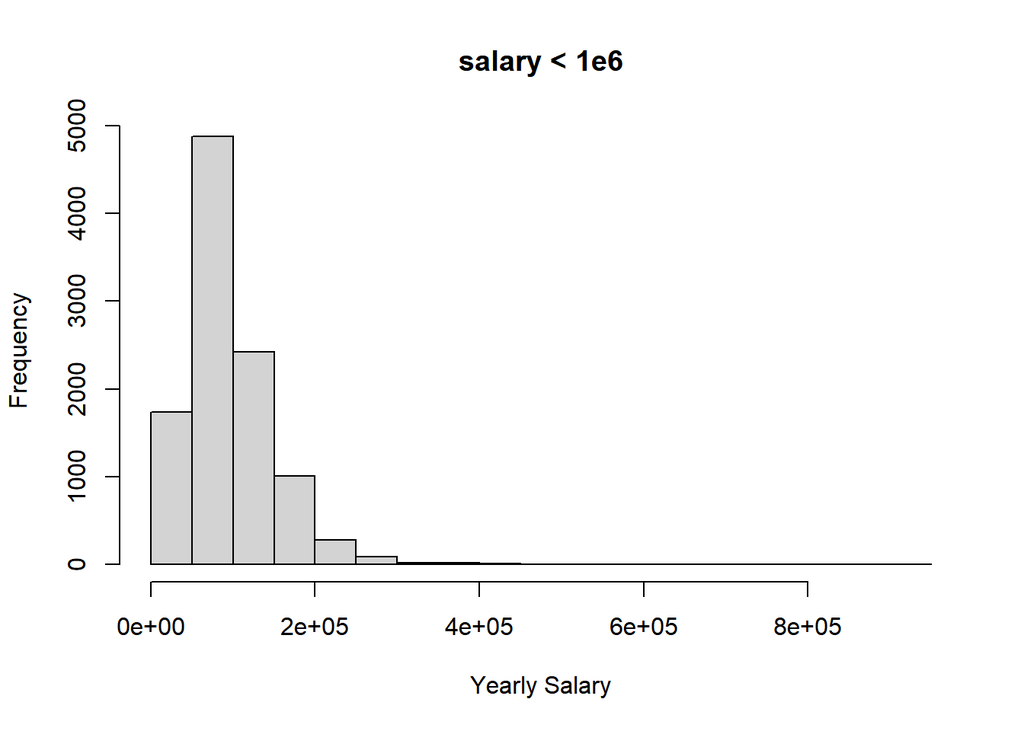

```r
# hist
hist(filtered[filtered$salary_yearly < 1e6,]$salary_yearly,
     main = "salary < 1e6",
     xlab = "Yearly Salary"
    )
```

```r
# use z score to eliminate outliers
filtered$z_score <- (filtered$salary_yearly-mean(filtered$salary_yearly))/
                    sd(filtered$salary_yearly)
mean(filtered$salary_yearly)-3*sd(filtered$salary_yearly)
```

```
[1] -162248.3
```

```r
# final result
final <- filtered[filtered$salary_yearly > 300 & filtered$z_score < 3, ]
cat("The final sample size is:", nrow(final))
```

```
The final sample size is: 10385
```

## Problem 3 - Palindromic

## a. Write isPalindromic

```r
#' isPalindromic
#' @param x (positive integer)
#' @return a list with 2 elements:
#'      isPalindromic:A logical value indicating if the input is palindromic.
#'      reversed: The input with its digits reversed.
#' @export
#'
#' @examples
#'

isPalindromic <- function(x){
  # stop when x is a negative number or is not an integer
  if(x < 0) stop("Input is negative.")
  if(x %% 1 != 0) stop("Input is not an integer.")
  # return result if x = 0, stop if x ends with 0 (not reversible)
  if(x == 0){
    return (list("isPlindormic" = TRUE, " reversed" = 0))
  }else if(x %% 10 == 0){
    stop("x is not reversible.")
  }else{
    # turn x into characters
    origin <- as.character(x)
    origin_split <- strsplit(origin, split = "") # string to list of letters
    len <- length(origin_split[[1]])
    reversed_split <- origin_split[[1]][len:1] # reverse list using index
    reversed <- paste(reversed_split, collapse = "") # paste the reverse list
    if(origin == reversed){
      isPalindromic <- TRUE
    }else{
        isPalindromic <- FALSE
    }
  }
    return
      (list("isPalindromic" = isPalindromic, "reversed" = as.integer(reversed)))   }
```

```r
# test
isPalindromic(728827)
```

```
$isPalindromic
[1] TRUE

$reversed
[1] 728827
```

## b. Write nextPalindrome

### method 1

I combined enumeration and many condition select and judegement to form the function.

```r
#' nextPalindrome1
#'
#' @param x Positive integer
#'
#' @return the next palidromic number
#' @export
#'
#' @examples
nextPalindrome <- function(x){
  # stop when x is negative or is not an integer
  if(x < 0) stop("Input is negative.")
  if(x %% 1 != 0) stop("Input is not an integer.")
  # for single digit x less than 9, nextPalindrome is x+1
  if(x<=8){
    return (x+1)
  }else{
    # calculate the number of digits
    ## turn input into chracter
    origin <- as.character(x)
    origin_split <- as.integer(strsplit(origin, split = "")[[1]])
    len <- length(origin_split)
    # we first use enumeration to find the nextPalindrome, the enumeration range is from x+1 to
    # end_search. Ex.input = 12345, range = 12346-12400; input = 1267, range = 1268-1300.
    # If we fail to find one by numeration, we construct nextpalindrome.
    digit <- len %/% 2
    end_search <- x %/% (10^digit)*10^digit + 10^digit
    # conduct enmeration
    for(i in seq(x+1, end_search)){
      # skip if a number is not invertible during enumeration.
      skip <- FALSE
      tryCatch(isPa <- isPalindromic(i)$isPalindromic,
               error = function(e){skip <<- TRUE})
      if(skip == TRUE) next
      if(isPa == TRUE) return(i)
    }
    # if enumeration fail, we construct next palindrome.
    mid <- len/2
    new_split <- origin_split
    # there are 2 different ways to construct next palindrome for numbers with odd and even digits.
    if(mid %% 1 != 0){
      mid <- len%/%2 + 1
    # for numbers with odd digits, if the middle digit is 9, take 1469543 as an
    #  example, we already knew that 1469544-1470000 are not palindromic, in this
    # case, we starts from 1470000, fix number 147 0 and reverse 147, add to the
    #  end. if middle digit is not 9, say, 15678, we simply add 1 to the middle
    # digit and turn 2:mid-1 digit to 0, fix digit 1:mid and reverse 1:mid-1, ex.
    # 15678 -> 15778 -> 10779 -> 10701
     if(origin_split[mid]!=9){
       new_split[mid] <- new_split[mid] + 1
       if(mid+1 <= len-1) new_split[(mid+1):len-1] <- 0
       if(2 <= mid-1) new_split[2:mid-1] <- 0
       new_split[len] <- new_split[1]
     }else{
        if(all(origin_split[1:mid] == 9) == TRUE){
          return (10^(2*mid-1)+1)
        }else{
          end_search <- as.character(end_search)
          end_search_split <- as.integer(strsplit(end_search, split = "")[[1]])
          new_split <- end_search_split
          new_split[(mid+1):len] <- new_split[mid-1:1]
        }
     }
    }else{
        if(origin_split[mid]!=9){
          new_split[mid] <- new_split[mid]+1
          new_split[(mid+1):len] <- new_split[mid:1]
        }else{
            if(all(origin_split[1:mid] == 9) == TRUE){
              return (10^(2*mid)+1)
            }else{
                end_search <- as.character(end_search)
                end_search_split <- as.integer(strsplit(end_search,
                                                        split = "")[[1]])
                new_split <- end_search_split
                new_split[(mid+1):len] <- new_split[mid:1]
            }
        }
    }
    res <- paste(as.character(new_split), collapse = "")
    return(as.integer(res))
  }
  }
```

### method 2 enumeration

I use enumeration to form the function.

```r
#' nextPalindrome1
#'
#' @param x Positive integer
#'
#' @return the next palidromic number
#' @export
#'
#' @examples
nextPalindrome1 <- function(x){
  # stop when x is negative or is not an integer
  if(x < 0){
    stop("Input is negative.")
  }
  if(x %% 1 != 0){
    stop("Input is not an integer.")
  }

  origin <- as.character(x)
  origin_split <- as.integer(strsplit(origin, split = "")[[1]])
  len <- length(origin_split)

  # find the range of enumeration
  if(len/2 %% 1 == 0){
    digit <- len / 2
    end_search <- x %/% (10^digit)*10^digit + 10^digit
  }else{
    digit <- len %/% 2 + 1
    end_search <- x %/% (10^digit)*10^digit + 10^digit
  }
  for(i in seq(x+1, end_search)){
      # skip if a number is not invertible during enumeration.
      skip <- FALSE
      tryCatch(isPa <- isPalindromic(i)$isPalindromic,
               error = function(e){skip <<- TRUE})
      if(skip == TRUE) next
      if(isPa == TRUE) return(i)
  }


}
```

## c. Test

```r
# test nextPlindrome
cat(
  " Input: 391, Output:", nextPalindrome(391), "\n",
  "Input: 9928, Output:", nextPalindrome(9928), "\n",
  "Input: 19272719, Output:", nextPalindrome(19272719), "\n",
  "Input: 109, Output:", nextPalindrome(109), "\n",
  "Input: 2, Output:", nextPalindrome(2), "\n"
  )
```

```
 Input: 391, Output: 393
 Input: 9928, Output: 9999
 Input: 19272719, Output: 19277291
 Input: 109, Output: 111
 Input: 2, Output: 3
```

```r
# test nextPlindrome1
cat(
  " Input: 391, Output:", nextPalindrome1(391), "\n",
  "Input: 9928, Output:", nextPalindrome1(9928), "\n",
  "Input: 19272719, Output:", nextPalindrome1(19272719), "\n",
  "Input: 109, Output:", nextPalindrome1(109), "\n",
  "Input: 2, Output:", nextPalindrome1(2), "\n"
  )
```

```
 Input: 391, Output: 393
 Input: 9928, Output: 9999
 Input: 19272719, Output: 19277291
 Input: 109, Output: 111
 Input: 2, Output: 3
```